# Analyzing TCGA (patient) Imputation Data

Robert F. Gruener

date last edited: 17 February, 2021

Analysis outline:

- Install TCGAbiolinks to get TCGA clinical data
- Format BRCA predictions, merge with clinical data
- Perform t-tests and correct for multiple testing
- Graph results for AZD-1775

```r
query <- GDCquery(project = "TCGA-BRCA",
                  data.category = "Clinical",
                  data.type = "Clinical Supplement",
                  data.format = "BCR Biotab")
```

[output not shown]

```r
GDCdownload(query)
```

```
Downloading data for project TCGA-BRCA
Of the 9 files for download 9 already exist.
All samples have been already downloaded
```

```r
clinical.BCRtab.all <- GDCprepare(query)
names(clinical.BCRtab.all)
```

```
[1] "clinical_follow_up_v2.1_brca"     "clinical_follow_up_v4.0_nte_brca" "clinical_radiation_brca"
[4] "clinical_omf_v4.0_brca"           "clinical_patient_brca"            "clinical_follow_up_v4.0_brca"
[7] "clinical_drug_brca"               "clinical_nte_brca"                "clinical_follow_up_v1.5_brca"
```

```r
BRCA_clinical <- clinical.BCRtab.all$clinical_patient_brca %>%
    dplyr::select(bcr_patient_barcode, er_status_by_ihc, er_status_ihc_Percent_Positive, pr_status_by_ihc,
                  pr_status_ihc_percent_positive, her2_status_by_ihc, her2_fish_status, ) %>%
    dplyr::slice(-1:-2) %>%
    type_convert() %>%
    mutate(HER2_Subtype = if_else(condition = her2_fish_status %in% c("Positive", "Negative"), her2_fish_status, her2_status_by_ihc)) %>%
    filter(er_status_by_ihc %in% c("Positive", "Negative"),
           pr_status_by_ihc %in% c("Positive", "Negative"),
           HER2_Subtype %in% c("Positive", "Negative")) %>%
    mutate(Clin_Subtype = if_else(condition = er_status_by_ihc == "Positive" | pr_status_by_ihc == "Positive",
                                  true = if_else(condition = HER2_Subtype == "Positive", true = "ER/PR+, HER2+", false = "ER/PR+"),
                                  false = if_else(condition = HER2_Subtype == "Positive", true = "HER2+", false = "TNBC"))) %>%
    mutate(TNBC_status = if_else(Clin_Subtype == "TNBC", "TNBC", "RPBC"))
TCGA_subs <- TCGAquery_subtype(tumor = "brca") #easily get TCGA PAM50 status this way
```

```
brca subtype information from:doi.org/10.1016/j.ccell.2018.03.014
```

```r
BRCA_pam50 <- TCGA_subs %>% dplyr::select(patient, PAM50 = BRCA_Subtype_PAM50) %>% filter(PAM50 != "NA")

BRCA_clinical <- full_join(BRCA_clinical, BRCA_pam50, by = c("bcr_patient_barcode" = "patient"))
```

Ki-67 staining is not available in TCGA, so we cannot do the traditional Lum A and Lum B groups for the clinical subtyping of ER+ tumors. However, this doesn’t impact us too much as there we are focused on TNBC which can be easily defined in our dataset.

### Filtering drugs based on the cross-validation results

It shouldn’t be expected that every drug should be modeled accurately whether this is due to inconsistency of the screening data or problems with sample size or other model variables.

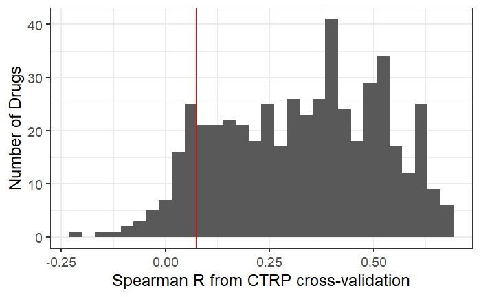

```r
CTRP_cv <- read_csv("./DataOut/20FoldCV_CTRP.csv")
CTRP_cv <- CTRP_cv %>%
  filter(!grepl(pattern = "mol/mol", Drug))

cv_cutoff <- CTRP_cv %>%
  filter(Spearman_Pvalue < 0.05,
         Spearman_Correlation > 0)

bad_cv_drugs <- anti_join(CTRP_cv, cv_cutoff)
bad_cv_drugs <- bad_cv_drugs$Drug


sup1 <- CTRP_cv %>% ggplot(aes(x = Spearman_Correlation)) +
  geom_histogram() +
  geom_vline(xintercept = min(cv_cutoff$Spearman_Correlation), color = "red") +
  labs(x = "Spearman R from CTRP cross-validation", y = "Number of Drugs") +
  theme_bw(base_size = 18)
sup1
ggsave(plot = sup1, device = "eps", filename = "supplemental_figure_1.eps")
```

```r
drug_targets <- read_csv("./Included_Data/Drug_targets(review).csv") # From Ling and Gruener et al
median(cv_cutoff$Spearman_Correlation)
```

```
[1] 0.385615
```

```r
cv_targets <- cv_cutoff %>%
  left_join(., drug_targets, by = c("Drug" = "Name in Database")) %>%
  dplyr::select(-Database) %>%
  distinct() %>%
  filter(!Targets %in% c("#N/A", "0"))

length(unique(unlist(strsplit(cv_targets$Targets, split = "\\|"))))
```

```
[1] 440
```

### Tamoxifen imputated sensitivity and ER+ breast cancers

We have reported on HER2 inhibitors in HER2 positive cancers previously, we can look for another proof-of-concept by looking at which drugs associate with the ER-positive BRCA cohort. We’ll do a similar test, stratify between ER+ and non-ER+ and perform a t-test between the two, and look for the compounds that associate with the ER+ subset.

```r
#first how many patients
preds.subtype %>% select(Patient_ID, Clin_Subtype) %>% distinct() %>% count(Clin_Subtype)
```

|  | Clin_Subtype | n |
| --- | --- | --- |
| 1 | ER/PR+ | 597 |
| 2 | ER/PR+, HER2+ | 140 |
| 3 | HER2+ | 38 |
| 4 | TNBC | 160 |

```r
preds.subtype %>% select(Patient_ID, PAM50) %>% distinct() %>% count(PAM50)
```

|  | PAM50 | n |
| --- | --- | --- |
| 1 | Basal | 167 |
| 2 | Her2 | 70 |
| 3 | LumA | 485 |
| 4 | LumB | 179 |
| 5 | Normal | 34 |

```r
preds.subtype %>% select(Drug) %>% distinct() %>% count(Drug)
```

|  | Drug | n |
| --- | --- | --- |
| 1 | 16-beta-bromoandrosterone | 1 |
| 2 | 1S,3R-RSL-3 | 1 |
| 3 | 3-Cl-AHPC | 1 |
| 4 | AA-COCF3 | 1 |
| 5 | ABT-199 | 1 |
| 6 | ABT-737 | 1 |
| 7 | AC55649 | 1 |
| 8 | afatinib | 1 |
| 9 | AGK-2 | 1 |
| 10 | alisertib | 1 |

[output cut: 417 more lines]

```r
NA
NA
NA
```

```r
###########ER and Tamoxifen Response#################

#ER and Tamoxifen stats:

ER_t.tst_preds <- preds.subtype %>%
  group_by(Drug) %>%
  drop_na(er_status_by_ihc) %>%
  do(tidy(t.test(PSS~er_status_by_ihc, data = .))) %>%
  ungroup() %>%
  mutate(bonf_p.value = p.adjust(p.value, method = "bonferroni")) %>%
  mutate(log10_p.correct = -log10(bonf_p.value)) %>%
  arrange(bonf_p.value)

dplyr::filter(ER_t.tst_preds, estimate > 0)
```

| Drug | estimate | estimate1 | estimate2 | statistic | p.value | parameter | conf.low | conf.high | method | alternative | bonf_p.value | log10_p.correct |
| --- | --- | --- | --- | --- | --- | --- | --- | --- | --- | --- | --- | --- |
| BCL-LZH-4 | 2.126811e-01 | 14.848282 | 14.635601 | 19.498897294 | 2.969032e-55 | 299.7819 | 0.1912164060 | 0.23414570 | Welch Two Sample t-test | two.sided | 1.267777e-52 | 51.89695720 |
| nilotinib | 2.566819e-01 | 14.375106 | 14.118424 | 18.465017481 | 1.013813e-51 | 306.8684 | 0.2293285798 | 0.28403519 | Welch Two Sample t-test | two.sided | 4.328982e-49 | 48.36361422 |
| tamoxifen | 1.241267e-01 | 14.229781 | 14.105654 | 17.124841986 | 2.996090e-45 | 275.1200 | 0.1098574452 | 0.13839596 | Welch Two Sample t-test | two.sided | 1.279330e-42 | 41.89301726 |
| BRD-K71935468 | 1.538157e-01 | 13.931727 | 13.777911 | 16.432597341 | 1.329860e-42 | 271.6271 | 0.1353875260 | 0.17224384 | Welch Two Sample t-test | two.sided | 5.678502e-40 | 39.24576621 |
| BRD-M00053801 | 1.766797e-01 | 13.697760 | 13.521080 | 13.879839479 | 9.134777e-34 | 283.0247 | 0.1516237429 | 0.20173571 | Welch Two Sample t-test | two.sided | 3.900550e-31 | 30.40887417 |
| ABT-199 | 4.259918e-01 | 14.293134 | 13.867143 | 12.898007764 | 9.753380e-31 | 308.5322 | 0.3610037646 | 0.49097992 | Welch Two Sample t-test | two.sided | 4.164693e-28 | 27.38041698 |
| VAF-347 | 2.456762e-01 | 15.144905 | 14.899228 | 12.880422232 | 1.488648e-30 | 301.9220 | 0.2081421696 | 0.28321029 | Welch Two Sample t-test | two.sided | 6.356527e-28 | 27.19678010 |
| salermide | 2.419650e-01 | 13.742802 | 13.500837 | 12.356345032 | 1.260799e-28 | 299.7061 | 0.2034288870 | 0.28050112 | Welch Two Sample t-test | two.sided | 5.383611e-26 | 25.26892629 |
| SB-525334 | 2.619393e-01 | 14.002425 | 13.740486 | 12.248646282 | 3.333893e-28 | 297.3673 | 0.2198538711 | 0.30402475 | Welch Two Sample t-test | two.sided | 1.423572e-25 | 24.84662051 |
| BRD-K33199242 | 1.272752e-01 | 14.930071 | 14.802796 | 11.721477359 | 4.201553e-26 | 281.2042 | 0.1059013207 | 0.14864900 | Welch Two Sample t-test | two.sided | 1.794063e-23 | 22.74616230 |

[output cut: 107 more lines]

```r
#ER positivity associates with Imputed Tamoxifen Response, it is the 3th most significant result
```

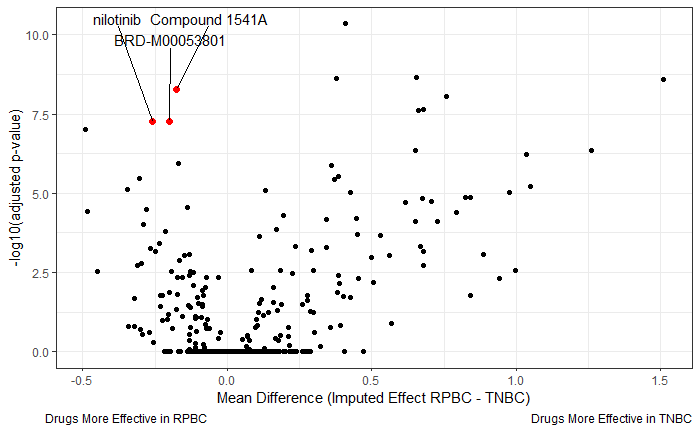

```r
lum_t.tst_preds <- preds.subtype %>%
  filter(Clin_Subtype %in% c("ER/PR+", "HER2+")) %>%
  group_by(Drug) %>%
  do(tidy(t.test(PSS~Clin_Subtype, data = .))) %>%
  ungroup() %>%
  mutate(bonf_p.value = p.adjust(p.value, method = "bonferroni")) %>%
  mutate(log10_p.correct = -log10(bonf_p.value)) %>%
  arrange(bonf_p.value)

lum_t.tst_preds %>%
  filter(estimate < 0) %>%
  arrange(desc(log10_p.correct)) %>%
  dplyr::slice(1:3) %>%
  ggplot(mapping = aes(x = estimate, y = log10_p.correct, label = Drug)) +
    geom_point(data = lum_t.tst_preds) +
    geom_point(color = "red", size = 2.2) +
    geom_text_repel(nudge_y = 3) +
    labs(y = "-log10(adjusted p-value)",
         x = "Mean Difference (Imputed Effect RPBC - TNBC)",
         caption = "Drugs More Effective in RPBC                                                                                                            Drugs More Effective in TNBC") +
    theme(plot.title = element_text(hjust = 0.5))
```

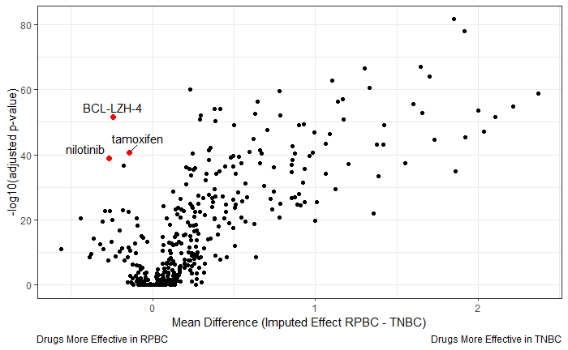

```r
lum_t.tst_preds <- preds.subtype %>%
  filter(Clin_Subtype %in% c("ER/PR+", "TNBC")) %>%
  group_by(Drug) %>%
  do(tidy(t.test(PSS~Clin_Subtype, data = .))) %>%
  ungroup() %>%
  mutate(bonf_p.value = p.adjust(p.value, method = "bonferroni")) %>%
  mutate(log10_p.correct = -log10(bonf_p.value)) %>%
  arrange(bonf_p.value)

lum_t.tst_preds %>%
  filter(estimate < 0) %>%
  arrange(desc(log10_p.correct)) %>%
  dplyr::slice(1:3) %>%
  ggplot(mapping = aes(x = estimate, y = log10_p.correct, label = Drug)) +
    geom_point(data = lum_t.tst_preds) +
    geom_point(color = "red", size = 2.2) +
    geom_text_repel(nudge_y = 3) +
    labs(y = "-log10(adjusted p-value)",
         x = "Mean Difference (Imputed Effect RPBC - TNBC)",
         caption = "Drugs More Effective in RPBC                                                                                                            Drugs More Effective in TNBC") +
    theme(plot.title = element_text(hjust = 0.5))
```